# Introduction to Unix and the Command Line

## Hardware, software, and Operating Systems

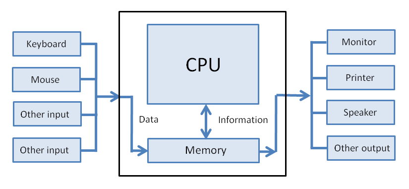

## Interfaces

How we interact with the computer (input and output)

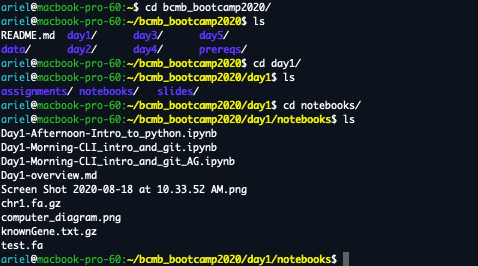

## File Systems

- control data storage and retrieval by partitioning files and controlling access

# Now Let's Code Along

In the remainder of this document we are demonstrating how to run a shell command within a python notebook by starting each cell with `%%bash`. This tells the python interpreter to utilize your computers Unix-like system (either the MacOSX operating system or the Linux distribution WSL2, installed by Windows users). If you do not wish to use a python notebook, you can open up a terminal directly in VSCode by going to `Terminal > New Terminal` and enter the commands directly into the command line *without* using `%%bash` preceding the command. See the command line interface screenshot above as an example.

### Option 1: Open a Terminal in VSCode

[figure not shown]

### Option 2: Open a Python Notebook

Launch VSCode and click to create a new file

[figure not shown]

Select `Jupyter Notebook` from the dropdown menu. This will create a new python notebook file with the `.ipynb` extension.

### Navigating the File System

The first thing we need to figure out is 'where are we' in the file system. To do this, we want to '_*P**rint the* *W**orking* *D*_irectory' using the command `pwd`

Note: to run the cell press Shift+Enter. This runs your current cell and creates a new cell for you to continue coding

```python
%%bash
pwd
```

```
/Users/loyalgoff/Library/CloudStorage/GoogleDrive-loyalgoff@gmail.com/My Drive/Work/Goff Lab/Teaching/Quantitative Neurogenomics/2023/course_materials/quant_mol_neuro_2023/modules/prereqs
```

We can list the contents of the directory using the built-in program `ls`

```python
%%bash
ls
```

```
Prereq-CLI_intro.html
Prereq-CLI_intro.ipynb
Prereq_Intro_to_python_part1.ipynb
Prereq_intro_git_and_GitHub.ipynb
images
```

#### Options/Input arguments

Bash/shell commands can take input arguments or options. One convention is to use a dash (`-`) to specify arguments. For example, we can ask `ls` to show a more detailed list of information for each file/folder:

```python
%%bash
ls -l
```

```
total 7080
-rw-------@ 1 loyalgoff  staff  1663118 Aug 17 08:28 Prereq-CLI_intro.html
-rw-------@ 1 loyalgoff  staff  1094530 Aug 17 08:23 Prereq-CLI_intro.ipynb
-rw-------@ 1 loyalgoff  staff    34127 Aug 28  2022 Prereq_Intro_to_python_part1.ipynb
-rw-------@ 1 loyalgoff  staff   822411 Aug 28  2022 Prereq_intro_git_and_GitHub.ipynb
drwxr-xr-x@ 2 loyalgoff  staff       64 Aug 17 08:14 images
```

We can aggregate different options by directly appending options one after another. The following shows how to display file sizes in human readable formats (`-h`):

```python
%%bash
ls -lh
```

```
total 7080
-rw-------@ 1 loyalgoff  staff   1.6M Aug 17 08:28 Prereq-CLI_intro.html
-rw-------@ 1 loyalgoff  staff   1.0M Aug 17 08:23 Prereq-CLI_intro.ipynb
-rw-------@ 1 loyalgoff  staff    33K Aug 28  2022 Prereq_Intro_to_python_part1.ipynb
-rw-------@ 1 loyalgoff  staff   803K Aug 28  2022 Prereq_intro_git_and_GitHub.ipynb
drwxr-xr-x@ 2 loyalgoff  staff    64B Aug 17 08:14 images
```

Sometimes commands take in arguments for various purposes. Again, using `ls` as example, it can take path as an argument. Without the path, it will by default show the current listings, as shown above. Given a path, it will list items in that path. The following command lists all the files and directories in the directory directly above your current directory:

```python
%%bash
ls ../
```

```
module1
prereqs
```

### Manual Pages (man)

It is certainly not expected that you memorize all arguments for every command. This is where the manual (`man`) comes in handy. You can use `man command_name` to find information about how to use a specific command. For example:

```python
%%bash
man ls
```

```
LS(1)                       General Commands Manual                      LS(1)

NAME
     ls – list directory contents

SYNOPSIS
     ls [-@ABCFGHILOPRSTUWabcdefghiklmnopqrstuvwxy1%,] [--color=when]
        [-D format] [file ...]

DESCRIPTION
     For each operand that names a file of a type other than directory, ls
     displays its name as well as any requested, associated information.  For
     each operand that names a file of type directory, ls displays the names
     of files contained within that directory, as well as any requested,
     associated information.

     If no operands are given, the contents of the current directory are
     displayed.  If more than one operand is given, non-directory operands are
     displayed first; directory and non-directory operands are sorted
     separately and in lexicographical order.

     The following options are available:

     -@      Display extended attribute keys and sizes in long (-l) output.

     -A      Include directory entries whose names begin with a dot (‘.’)
             except for . and ...  Automatically set for the super-user unless
             -I is specified.

     -B      Force printing of non-printable characters (as defined by
             ctype(3) and current locale settings) in file names as \xxx,
             where xxx is the numeric value of the character in octal.  This
             option is not defined in IEEE Std 1003.1-2008 (“POSIX.1”).

     -C      Force multi-column output; this is the default when output is to
             a terminal.

     -D format
             When printing in the long (-l) format, use format to format the
             date and time output.  The argument format is a string used by
```

[output cut: 465 more lines]

```
     An ls command appeared in Version 1 AT&T UNIX.

BUGS
     To maintain backward compatibility, the relationships between the many
     options are quite complex.

     The exception mentioned in the -s option description might be a feature
     that was based on the fact that single-column output usually goes to
     something other than a terminal.  It is debatable whether this is a
     design bug.

     IEEE Std 1003.2 (“POSIX.2”) mandates opposite sort orders for files with
     the same timestamp when sorting with the -t option.

macOS 13.0                      August 31, 2020                     macOS 13.0
```

```
Unknown locale, assuming C
```

Here, man is a command that takes one input argument (which should be a Bash command) and outputs the corresponding manual.

## Creating and Navigating Folders

Now that we have a basic overview of how to interact with the computer in bash, it will be useful to understand how to create folders (directories) and navigate around our system. We've already used the `pwd` command to learn where we currently are. But what if we wanted to make a new directory to contain a project?

The `mkdir` command stands for “make directory”. It takes in a directory name as an *argument*, and then creates a new directory in the current working directory.

```python
%%bash
mkdir myDirectory
```

Nothing seemed to happen? Lets check and see if our new directory was made:

```python
%%bash
ls -l
```

```
total 7080
-rw-------@ 1 loyalgoff  staff  1663118 Aug 17 08:28 Prereq-CLI_intro.html
-rw-------@ 1 loyalgoff  staff  1094530 Aug 17 08:23 Prereq-CLI_intro.ipynb
-rw-------@ 1 loyalgoff  staff    34127 Aug 28  2022 Prereq_Intro_to_python_part1.ipynb
-rw-------@ 1 loyalgoff  staff   822411 Aug 28  2022 Prereq_intro_git_and_GitHub.ipynb
drwxr-xr-x@ 2 loyalgoff  staff       64 Aug 17 08:14 images
drwxr-xr-x  2 loyalgoff  staff       64 Aug 17 08:31 myDirectory
```

There it is, lets try and move into the directory.

`cd` stands for “change directory”. Just as you would click on a folder in Windows Explorer or Finder on a Mac, `cd` switches you into the directory you specify. In other words, `cd` changes the working directory.

```python
%%bash
cd myDirectory
pwd
```

```
/Users/loyalgoff/Library/CloudStorage/GoogleDrive-loyalgoff@gmail.com/My Drive/Work/Goff Lab/Teaching/Quantitative Neurogenomics/2023/course_materials/quant_mol_neuro_2023/modules/prereqs/myDirectory
```

Note that within the above cell, you actually ran two commands in Bash, one right after the other. You first changed your location within the file system by using the `cd` command. Then you used the `pwd` command to list out your current location in the file system. All scripting will follow this type of linear instruction list unless we create a loop (more on that later!).

```python
%%bash
cd ..
pwd
```

```
/Users/loyalgoff/Library/CloudStorage/GoogleDrive-loyalgoff@gmail.com/My Drive/Work/Goff Lab/Teaching/Quantitative Neurogenomics/2023/course_materials/quant_mol_neuro_2023/modules
```

And finally, we can remove an (empty) directory using `rmdir`.

```python
%%bash
rmdir myDirectory
ls
```

```
Prereq-CLI_intro.html
Prereq-CLI_intro.ipynb
Prereq_Intro_to_python_part1.ipynb
Prereq_intro_git_and_GitHub.ipynb
images
```

### Review

- The command line is a text interface for the computer’s operating system. To access the command line, we use the terminal.
- A filesystem organizes a computer’s files and directories into a tree. It starts with the root directory. Each parent directory can contain more child directories and files.
- From the command line, you can navigate through files and folders on your computer
  - `pwd` outputs the name of the current working directory.
  - `ls` lists all files and directories in the working directory.
  - `cd` switches you into the directory you specify.
  - `mkdir` creates a new directory in the working directory.
  - `rmdir` removes an empty directory

## Viewing and changing files

### Creating files

There are several ways to create a file. One of the easiest is to just create an empty file by touching it (`touch`)

```python
%%bash
touch myBrandNewFile.txt
```

```python
%%bash
ls -l
```

```
total 7080
-rw-------@ 1 loyalgoff  staff  1663118 Aug 17 08:28 Prereq-CLI_intro.html
-rw-------@ 1 loyalgoff  staff  1094530 Aug 17 08:23 Prereq-CLI_intro.ipynb
-rw-------@ 1 loyalgoff  staff    34127 Aug 28  2022 Prereq_Intro_to_python_part1.ipynb
-rw-------@ 1 loyalgoff  staff   822411 Aug 28  2022 Prereq_intro_git_and_GitHub.ipynb
drwxr-xr-x@ 2 loyalgoff  staff       64 Aug 17 08:14 images
-rw-r--r--  1 loyalgoff  staff        0 Aug 17 08:31 myBrandNewFile.txt
```

## Side Note about Wildcards and tab complete

- The * matches one or more occurrence of any character
- The ? matches a single occurrence of any character
- Another shortcut is tab completion, type the beginning of a file or directory, then hit tab for it to automatically fill in the rest

You just looked at the files that are in your current directory when you used `ls -l` and you should see your new file `myBrandNewFile.txt`. Let's test out using the wildcard and tab complete options.

I can attempt to list that file in the following two ways:

```python
%%bash
ls *.txt
```

```
myBrandNewFile.txt
```

#### OR

```python
%%bash
ls my?randNewFile.txt
```

```
myBrandNewFile.txt
```

Additionally, test out the tab complete option. In a new cell start typing the name of on of your files and press `Tab`. For example I would type:

```python
%%bash
#ls my #and then press the Tab key to complete the file name
```

Note: If you have not typed sufficient letters to identify a unique file, a list of potential files will pop up in a menu for you to select. In this example, the directory had multiple files that start with `Day1`:

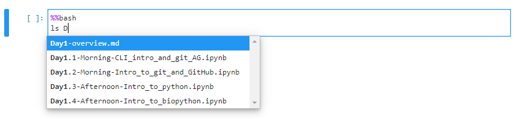

Side note over. Let's get back to writing files!

We created the file and gave it a name, but it is completely empty at this point. We can write directly to a file by *redirecting* some content into the file. This is achieved with the `>`. Imagine that this is an arrow pointing to where you want to put the output. Here we will also introduce you to the `echo` command which simply repeats the first argument (in this case the argument is the text 'Hello World'). Here we're going to have the output of `echo` *redirected* into our new file.

```python
%%bash
echo 'Hello World' > myBrandNewFile.txt
```

We can now view the contents of a file by using the command `cat` which returns the entire contents of the file.

```python
%%bash
cat myBrandNewFile.txt
```

```
Hello World
```

### Moving and removing files

The `mv` command has a couple of different uses. You can use it to move files from one directory to another (imagine moving a file from your 'Downloads' to your 'Desktop'). The `mv` command could also be used to rename files or directories. Let's first explore renaming our file using the `mv` command below which take the file to be moved as the primary argument and new name of the file as the secondary argument:

```python
%%bash
mv myBrandNewFile.txt myOlderFile.txt
ls -l
```

```
total 7088
-rw-------@ 1 loyalgoff  staff  1663118 Aug 17 08:28 Prereq-CLI_intro.html
-rw-------@ 1 loyalgoff  staff  1094530 Aug 17 08:23 Prereq-CLI_intro.ipynb
-rw-------@ 1 loyalgoff  staff    34127 Aug 28  2022 Prereq_Intro_to_python_part1.ipynb
-rw-------@ 1 loyalgoff  staff   822411 Aug 28  2022 Prereq_intro_git_and_GitHub.ipynb
drwxr-xr-x@ 2 loyalgoff  staff       64 Aug 17 08:14 images
-rw-r--r--  1 loyalgoff  staff       12 Aug 17 08:31 myOlderFile.txt
```

We now renamed our file to 'myOlderFile.txt'.

```python
%%bash
mkdir TemporaryDirectory
mv myOlderFile.txt TemporaryDirectory
cd TemporaryDirectory
pwd
ls
```

```
/Users/loyalgoff/Library/CloudStorage/GoogleDrive-loyalgoff@gmail.com/My Drive/Work/Goff Lab/Teaching/Quantitative Neurogenomics/2023/course_materials/quant_mol_neuro_2023/modules/prereqs/TemporaryDirectory
myOlderFile.txt
```

In the above cell we 1) made a new directory 2) moved our file into that directory 3) changed our location within the file system to our new directory 4) printed out our location 5) listed our currect directory contents

And finally, we can remove a file using the `rm` command. The `rm` command removes files or directories (removed files will be gone forever, proceed with caution):

```python
%%bash
rm myOlderFile.txt
ls -la
```

```
total 7080
drwx------@ 8 loyalgoff  staff      256 Aug 17 08:31 .
drwx------@ 4 loyalgoff  staff      128 Aug  9 16:15 ..
-rw-------@ 1 loyalgoff  staff  1663118 Aug 17 08:28 Prereq-CLI_intro.html
-rw-------@ 1 loyalgoff  staff  1094530 Aug 17 08:23 Prereq-CLI_intro.ipynb
-rw-------@ 1 loyalgoff  staff    34127 Aug 28  2022 Prereq_Intro_to_python_part1.ipynb
-rw-------@ 1 loyalgoff  staff   822411 Aug 28  2022 Prereq_intro_git_and_GitHub.ipynb
drwxr-xr-x  3 loyalgoff  staff       96 Aug 17 08:31 TemporaryDirectory
drwxr-xr-x@ 2 loyalgoff  staff       64 Aug 17 08:14 images
```

```
rm: myOlderFile.txt: No such file or directory
```

## Key Concept

You may have already noticed that in our file and directory names we do not use spaces. This is because bash commands often use spaces as a way to separate arguments. Spaces in the titles of your files or directories are interpreted by bash commands as additional arguments. Best practice is to use naming conventions like 'CamelCase' (where the first letter of a new word is capitalized) or use an underscore to separate words. Examples: MyNewFile.txt or my_new_file.txt

# File properties

We have now created, deleted, moved, and manipulated files, but what if we simply want to know more about their contects without actually changing them? For example, we can download a chromosome file from a database and learn more about its contents.

### Downloading files from the internet

We can use the `wget` command followed by the URL. The file will be downloaded into your current directory location. This may take a minute to download

```python
%%bash
wget http://sgd-archive.yeastgenome.org/sequence/S288C_reference/chromosomes/fasta/chr01.fsa
```

```
--2023-08-17 08:31:10--  http://sgd-archive.yeastgenome.org/sequence/S288C_reference/chromosomes/fasta/chr01.fsa
Resolving sgd-archive.yeastgenome.org (sgd-archive.yeastgenome.org)... 52.92.136.171, 52.92.242.99, 52.92.147.123, ...
Connecting to sgd-archive.yeastgenome.org (sgd-archive.yeastgenome.org)|52.92.136.171|:80... connected.
HTTP request sent, awaiting response... 200 OK
Length: 234177 (229K) [binary/octet-stream]
Saving to: ‘chr01.fsa’

     0K .......... .......... .......... .......... .......... 21%  266K 1s
    50K .......... .......... .......... .......... .......... 43% 15.4M 0s
   100K .......... .......... .......... .......... .......... 65%  790K 0s
   150K .......... .......... .......... .......... .......... 87% 1.45M 0s
   200K .......... .......... ........                        100%  569K=0.3s

2023-08-17 08:31:11 (676 KB/s) - ‘chr01.fsa’ saved [234177/234177]
```

### File sizes

The command `du`, which stands for 'disk usage' provides you with information about your file and directory sizes. If we pass our newly downloaded file 'chr01.fsa' to the command `du` as an argument, it will tell us size of our file.

```python
%%bash
du chr01.fsa

du -h chr01.fsa #outputs in 'human-readable' format (byte, kb, mb, etc)
```

```
464	chr01.fsa
232K	chr01.fsa
```

### File compression/uncompression

This is done using programs such as gzip/gunzip. File compression may be key when dealing with large file sizes such as sequencing data. Let's test it out!

```python
%%bash
gzip chr01.fsa # gzip command to compress the file, notice the new file extension of *.gz
du -h chr01.fsa.gz
gunzip chr01.fsa.gz # gunzip command to uncompress the file, removes the file extension
du -h chr01.fsa
```

```
 72K	chr01.fsa.gz
232K	chr01.fsa
```

In this example we are using gzip directly on the `chr01.fsa` file. If we wanted to zip the file, but keep the original unzipped file as well, we could use the `-k` argument. Test it out!

```python
%%bash
gzip -k chr01.fsa
```

To count the number of words, lines, and characters in your file you can use the command `wc`

```python
%%bash
wc -w chr01.fsa #words
wc -l chr01.fsa #lines
wc -m chr01.fsa #characters
```

```
    3845 chr01.fsa
    3838 chr01.fsa
  234177 chr01.fsa
```

### Ownership and Permissions

We have used `ls -lh` previously to look at the file in our directory, but now that we know a little bit more about the files and how to manipulate them, we should understand a little bit more about file ownership and permissions.

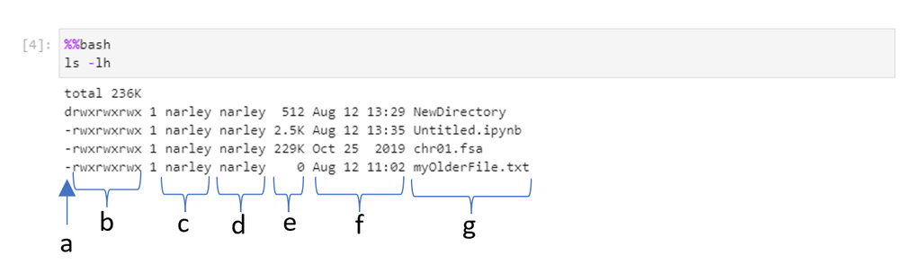

- the first line corresponds to the total size of all the files contained within the directory
- the remaining lines are each of the files or directories contained within that directory
- for each line the information is as follows:
  - a) the first character 'd' or '-' tells you if the item is a directory or file, repectively
  - b) characters 2-10 designate the permissions of the file owner (characters 2-4), group owner (characters 5-7), and all other users (characters 8-10)
    - 'r' for read which allows the contents of the file or directory to be read or listed
    - 'w' for write which allows the file or directory to be created, deleted, or edited
    - 'x' for execute which allows the file to perform commands or searching through a directory
  - c) identity of the current file owner
  - d) identity of the current file group
  - e) size of file or byte block size of the directory
  - f) date and time the file or directory was last modified
  - g) file or directory name

Many times users will run into error messages because they do not have appropriate permissions to read, write, or execute a file or directory. Keep this in mind for the future if you run into errors! You can `ls -lh` in your current directory to check out your own permissions.

```python
%%bash
ls -lh
```

```
total 7688
-rw-------@ 1 loyalgoff  staff   1.6M Aug 17 08:28 Prereq-CLI_intro.html
-rw-------@ 1 loyalgoff  staff   1.0M Aug 17 08:23 Prereq-CLI_intro.ipynb
-rw-------@ 1 loyalgoff  staff    33K Aug 28  2022 Prereq_Intro_to_python_part1.ipynb
-rw-------@ 1 loyalgoff  staff   803K Aug 28  2022 Prereq_intro_git_and_GitHub.ipynb
drwxr-xr-x@ 3 loyalgoff  staff    96B Aug 17 08:31 TemporaryDirectory
-rw-r--r--  1 loyalgoff  staff   229K Oct 25  2019 chr01.fsa
-rw-r--r--  1 loyalgoff  staff    70K Oct 25  2019 chr01.fsa.gz
drwxr-xr-x@ 2 loyalgoff  staff    64B Aug 17 08:14 images
```

# Viewing files

We previously used the command `cat` too look at the contents of small files. However, for large files (like our chromosome file with over 3000 lines, commands like `cat` are not particularly useful if we perhaps only need a small subset of that information. A few other commands we can use to view file content are `head` and `tail` which display the first 10 lines and the last 10 lines of the file, respectively. If you wish to view more, you can use the argument `-n`, for example, `head -n 20 <your_file_name>` would display the first 20 lines of your file.

```python
%%bash
head chr01.fsa
```

```
>tpg|BK006935.2| [organism=Saccharomyces cerevisiae S288c] [strain=S288c] [moltype=genomic] [chromosome=I] [note=R64-1-1]
CCACACCACACCCACACACCCACACACCACACCACACACCACACCACACCCACACACACA
CATCCTAACACTACCCTAACACAGCCCTAATCTAACCCTGGCCAACCTGTCTCTCAACTT
ACCCTCCATTACCCTGCCTCCACTCGTTACCCTGTCCCATTCAACCATACCACTCCGAAC
CACCATCCATCCCTCTACTTACTACCACTCACCCACCGTTACCCTCCAATTACCCATATC
CAACCCACTGCCACTTACCCTACCATTACCCTACCATCCACCATGACCTACTCACCATAC
TGTTCTTCTACCCACCATATTGAAACGCTAACAAATGATCGTAAATAACACACACGTGCT
TACCCTACCACTTTATACCACCACCACATGCCATACTCACCCTCACTTGTATACTGATTT
TACGTACGCACACGGATGCTACAGTATATACCATCTCAAACTTACCCTACTCTCAGATTC
CACTTCACTCCATGGCCCATCTCTCACTGAATCAGTACCAAATGCACTCACATCATTATG
```

```python
%%bash
tail -n 20 chr01.fsa
```

```
AAGACTGGTACCAAAGGTAATGCATCTACCTCCCGTTACTTTTCCGAATCAGACAGTGTT
TTGGTCGCACAAGGTGTCTCTGGCGCTGTCGTTGACAAAGGATCCATTAAGAAATTTATT
CCGTACTTGTACAATGGATTACAACATTCTTGTCAAGACATCGGCTGTAGGTCGTTAACT
TTACTAAAGGAAAATGTCCAAAGCGGTAAAGTTAGATTTGAATTCAGAACCGCTTCTGCT
CAACTAGAAGGTGGTGTTAATAACTTACATTCCTACGAAAAACGTTTACATAACTGAATG
TTAAATGGGATCATTAATACAATAGTACTGTACGTATGGCACCTGTACATACTGCGTTAT
AAATGTACTAATGGAATGATATATTAATATATAGTGTGTTTATACCTTATTATTGATGAT
TAGTATATATTTTTATATTTAGGTGATTTTAGTGGAGATTATTTGGTGGTAATTACACTA
GTATACATAAAATGGGTAGTGGATATTTGTATAGAAAGGGCATTACGCATGGAGTTAAGA
GTATTTACATGATAATTGGGGTTCCGTGATTCATTATAGATAATAAAACGTGGATAATAT
TGGGTGTTATAGGTAAATGGGACAGGGTATAGACCGCTGAGGCAAGTGCCGTGTATGGTG
ATGTGGTATGGTATCGAGTACCGATGGAGTGAGAGATGGCCTTGGTGTAGAGTATTATGG
CGGGTAAGTTAGATGATGTATTGTTTACGTTATATTTGTTTAAATTGGATTTGTTTACAT
TAGATTTGTTTACATTTCAATATATCAATGGAGGGTATGTAGCATTATGGTAAGTAGCAC
GTGGTAGATGGGGATTGTAGGTGGATGGTAGGATGAGTGGTAGTGAGAGTTGGATAAGAT
ATATTGGGCAGGGGATAGATGGTTGTTGGGGTGTGGTGATGGATAGTGAGTGGATAGTGA
GTGGATGGATGGTGGAGTGGGGGAATGAGACAGGGCATGGGGTGGTGAGGTAAGTGCCGT
GGATTGTGATGATGGAGAGGGAGGGTAGTTGACATGGAGTTAGAATTGGGTCAGTGTTAG
TGTTAGTGTTAGTATTAGGGTGTGGTGTGTGGGTGTGGTGTGGGTGTGGGTGTGGGTGTG
GGTGTGGGTGTGGGTGTGGTGTGGTGTGTGGGTGTGGTGTGGGTGTGGTGTGTGTGGG
```

One command that does not function similarly in a python notebook and the command line is the command `less`. In a python notebook using `less <your_file_name>` prints out the entire file. In the command line interface (either Terminal for Mac OSX or your Linux distribution for Windows), `less` displays the contents of a file, but does not print out the files contents. Try both and see the difference! First with the less command in a python notebook:

```python
%%bash
less chr01.fsa
```

```
>tpg|BK006935.2| [organism=Saccharomyces cerevisiae S288c] [strain=S288c] [moltype=genomic] [chromosome=I] [note=R64-1-1]
CCACACCACACCCACACACCCACACACCACACCACACACCACACCACACCCACACACACA
CATCCTAACACTACCCTAACACAGCCCTAATCTAACCCTGGCCAACCTGTCTCTCAACTT
ACCCTCCATTACCCTGCCTCCACTCGTTACCCTGTCCCATTCAACCATACCACTCCGAAC
CACCATCCATCCCTCTACTTACTACCACTCACCCACCGTTACCCTCCAATTACCCATATC
CAACCCACTGCCACTTACCCTACCATTACCCTACCATCCACCATGACCTACTCACCATAC
TGTTCTTCTACCCACCATATTGAAACGCTAACAAATGATCGTAAATAACACACACGTGCT
TACCCTACCACTTTATACCACCACCACATGCCATACTCACCCTCACTTGTATACTGATTT
TACGTACGCACACGGATGCTACAGTATATACCATCTCAAACTTACCCTACTCTCAGATTC
CACTTCACTCCATGGCCCATCTCTCACTGAATCAGTACCAAATGCACTCACATCATTATG
CACGGCACTTGCCTCAGCGGTCTATACCCTGTGCCATTTACCCATAACGCCCATCATTAT
CCACATTTTGATATCTATATCTCATTCGGCGGTCCCAAATATTGTATAACTGCCCTTAAT
ACATACGTTATACCACTTTTGCACCATATACTTACCACTCCATTTATATACACTTATGTC
AATATTACAGAAAAATCCCCACAAAAATCACCTAAACATAAAAATATTCTACTTTTCAAC
AATAATACATAAACATATTGGCTTGTGGTAGCAACACTATCATGGTATCACTAACGTAAA
AGTTCCTCAATATTGCAATTTGCTTGAACGGATGCTATTTCAGAATATTTCGTACTTACA
CAGGCCATACATTAGAATAATATGTCACATCACTGTCGTAACACTCTTTATTCACCGAGC
AATAATACGGTAGTGGCTCAAACTCATGCGGGTGCTATGATACAATTATATCTTATTTCC
ATTCCCATATGCTAACCGCAATATCCTAAAAGCATAACTGATGCATCTTTAATCTTGTAT
GTGACACTACTCATACGAAGGGACTATATCTAGTCAAGACGATACTGTGATAGGTACGTT
ATTTAATAGGATCTATAACGAAATGTCAAATAATTTTACGGTAATATAACTTATCAGCGG
CGTATACTAAAACGGACGTTACGATATTGTCTCACTTCATCTTACCACCCTCTATCTTAT
TGCTGATAGAACACTAACCCCTCAGCTTTATTTCTAGTTACAGTTACACAAAAAACTATG
CCAACCCAGAAATCTTGATATTTTACGTGTCAAAAAATGAGGGTCTCTAAATGAGAGTTT
GGTACCATGACTTGTAACTCGCACTGCCCTGATCTGCAATCTTGTTCTTAGAAGTGACGC
ATATTCTATACGGCCCGACGCGACGCGCCAAAAAATGAAAAACGAAGCAGCGACTCATTT
TTATTTAAGGACAAAGGTTGCGAAGCCGCACATTTCCAATTTCATTGTTGTTTATTGGAC
ATACACTGTTAGCTTTATTACCGTCCACGTTTTTTCTACAATAGTGTAGAAGTTTCTTTC
TTATGTTCATCGTATTCATAAAATGCTTCACGAACACCGTCATTGATCAAATAGGTCTAT
AATATTAATATACATTTATATAATCTACGGTATTTATATCATCAAAAAAAAGTAGTTTTT
TTATTTTATTTTGTTCGTTAATTTTCAATTTCTATGGAAACCCGTTCGTAAAATTGGCGT
TTGTCTCTAGTTTGCGATAGTGTAGATACCGTCCTTGGATAGAGCACTGGAGATGGCTGG
CTTTAATCTGCTGGAGTACCATGGAACACCGGTGATCATTCTGGTCACTTGGTCTGGAGC
AATACCGGTCAACATGGTGGTGAAGTCACCGTAGTTGAAAACGGCTTCAGCAACTTCGAC
TGGGTAGGTTTCAGTTGGGTGGGCGGCTTGGAACATGTAGTATTGGGCTAAGTGAGCTCT
GATATCAGAGACGTAGACACCCAATTCCACCAAGTTGACTCTTTCGTCAGATTGAGCTAG
AGTGGTGGTTGCAGAAGCAGTAGCAGCGATGGCAGCGACACCAGCGGCGATTGAAGTTAA
TTTGACCATTGTATTTGTTTTGTTTGTTAGTGCTGATATAAGCTTAACAGGAAAGGAAAG
AATAAAGACATATTCTCAAAGGCATATAGTTGAAGCAGCTCTATTTATACCCATTCCCTC
ATGGGTTGTTGCTATTTAAACGATCGCTGACTGGCACCAGTTCCTCATCAAATATTCTCT
```

[output cut: 3783 more lines]

```
TTAAATGGGATCATTAATACAATAGTACTGTACGTATGGCACCTGTACATACTGCGTTAT
AAATGTACTAATGGAATGATATATTAATATATAGTGTGTTTATACCTTATTATTGATGAT
TAGTATATATTTTTATATTTAGGTGATTTTAGTGGAGATTATTTGGTGGTAATTACACTA
GTATACATAAAATGGGTAGTGGATATTTGTATAGAAAGGGCATTACGCATGGAGTTAAGA
GTATTTACATGATAATTGGGGTTCCGTGATTCATTATAGATAATAAAACGTGGATAATAT
TGGGTGTTATAGGTAAATGGGACAGGGTATAGACCGCTGAGGCAAGTGCCGTGTATGGTG
ATGTGGTATGGTATCGAGTACCGATGGAGTGAGAGATGGCCTTGGTGTAGAGTATTATGG
CGGGTAAGTTAGATGATGTATTGTTTACGTTATATTTGTTTAAATTGGATTTGTTTACAT
TAGATTTGTTTACATTTCAATATATCAATGGAGGGTATGTAGCATTATGGTAAGTAGCAC
GTGGTAGATGGGGATTGTAGGTGGATGGTAGGATGAGTGGTAGTGAGAGTTGGATAAGAT
ATATTGGGCAGGGGATAGATGGTTGTTGGGGTGTGGTGATGGATAGTGAGTGGATAGTGA
GTGGATGGATGGTGGAGTGGGGGAATGAGACAGGGCATGGGGTGGTGAGGTAAGTGCCGT
GGATTGTGATGATGGAGAGGGAGGGTAGTTGACATGGAGTTAGAATTGGGTCAGTGTTAG
TGTTAGTGTTAGTATTAGGGTGTGGTGTGTGGGTGTGGTGTGGGTGTGGGTGTGGGTGTG
GGTGTGGGTGTGGGTGTGGTGTGGTGTGTGGGTGTGGTGTGGGTGTGGTGTGTGTGGG
```

Next, try using less by opening up a terminal.

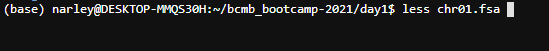

`less` displays the contents of the file and you can use it as follows:

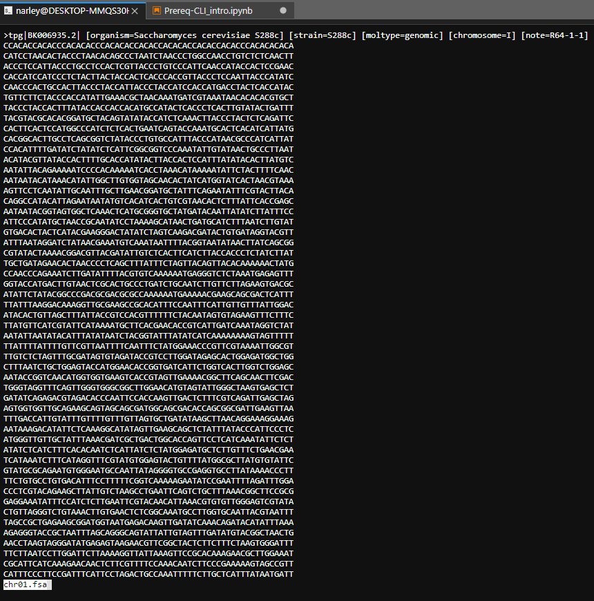

- use up and down arrows to scroll
- spacebar scrolls down 1 page at a time
- hit q to quit

# Searching in files

Rather than scanning through the entire 3000+ lines of the file, you can also use the `grep` command to pull out specific words or lines in the case of this chromosome file. Using the `-c` argument tells the `grep` command to return the number of times the pattern occurred.

```python
%%bash
grep "TACCCTACC" chr01.fsa
grep -c "TACCCTACC" chr01.fsa
```

```
CAACCCACTGCCACTTACCCTACCATTACCCTACCATCCACCATGACCTACTCACCATAC
TACCCTACCACTTTATACCACCACCACATGCCATACTCACCCTCACTTGTATACTGATTT
2
```

```python
%%bash
grep "TACC.TACC" chr01.fsa
grep -c "TACC.TACC" chr01.fsa
grep "TACC*TACC" chr01.fsa
grep -c "TACC*TACC" chr01.fsa
```

```
CAACCCACTGCCACTTACCCTACCATTACCCTACCATCCACCATGACCTACTCACCATAC
TACCCTACCACTTTATACCACCACCACATGCCATACTCACCCTCACTTGTATACTGATTT
TCAATTTTAGCCGCTTCTTTGGTTAATGCAGGTACCATACCCCTCGGAAAGTTATCTGAC
3
CACCATCCATCCCTCTACTTACTACCACTCACCCACCGTTACCCTCCAATTACCCATATC
CAACCCACTGCCACTTACCCTACCATTACCCTACCATCCACCATGACCTACTCACCATAC
TACCCTACCACTTTATACCACCACCACATGCCATACTCACCCTCACTTGTATACTGATTT
TTTGTAGACGGAATAAAGAACTTACCTCCGCCTTTACTACCTCAAGTGATTAATAATCCA
TTTGGTTTTGCTTATAGATAGAAAATATAAGAACAAGATATAACGTACTACCAGATAACC
TTCAAACCTGCTTAAAAACCTCGACAAACGAGCCCCCAACGTACTACCACAGCAACCACT
TAGTTGTCGACTACTACCTCCTCAACCCCAGTTATATCCCTATGACACATTGGAGGATGC
TATATGCTGAACTGTTACTACCTTATTTTTTCCGAAATGTTTCTAAAACAAATAAATATT
AAACTACGTGTATTTCACCTCTTTCTCGACTTGAACACGTCCAACTCCTTAAGTACTACC
ATTACTATATTCTCAACCCGCCGTTTTCCTGCTGTGCGATAATTCTCATTCAATACTACC
GAGGCATCATGGTACTACCGTGACGGAGAATACGTAGGCTGACTTTTTCGTCAGTTTGTT
CATACTGGAGTACTGATTTATTTGGTTTCTATACTACCCCAACAAACGTAACCCTAGAAA
ACATACTACTAGCATCGTCACAACTACTACCGAACTGTGGACTGGTACTTTTACTTCTAC
TTTATAACATATAAGAACTACTACCTCATGAATTCTAGTGGATGAAAGAAGCAGCACGAA
TTATATAATAACATCCGTATAAGTACATATACTACCATGTCTGTTCTCTACATTGCTTTT
TCTACTGTTATGATGGGTGGTATGTTGGCCGGTACTACCGAATCACCAGGTGAATATCTC
16
```

# Piping/redirection

Most of the commands that we have used thusfar have utilized a single command that returned its output to the command line. Perhaps you want to save the ouput of your command to a new file, which can be done using the redirect `>` symbol. Here we are taking the last 10 lines from the chr01.fsa file and writing them to a new file which we are calling *tail.txt*

```python
%%bash
tail -n 10 chr01.fsa > tail.txt
```

```python
%%bash
cat chr01.fsa | head -n 10 | tail -n 5
```

```
CAACCCACTGCCACTTACCCTACCATTACCCTACCATCCACCATGACCTACTCACCATAC
TGTTCTTCTACCCACCATATTGAAACGCTAACAAATGATCGTAAATAACACACACGTGCT
TACCCTACCACTTTATACCACCACCACATGCCATACTCACCCTCACTTGTATACTGATTT
TACGTACGCACACGGATGCTACAGTATATACCATCTCAAACTTACCCTACTCTCAGATTC
CACTTCACTCCATGGCCCATCTCTCACTGAATCAGTACCAAATGCACTCACATCATTATG
```

### You made it through this intro! Great job!

Let the Instructor or TAs know if you have any questions and we will expand upon these lessons in class.